# Get to know me!

Laeticia Liawas

2026-01-27

# This R Markdown is to get to know Laeticia!

## Bio

My name is Laeticia! I am a 4th year at UofT as of writing this. My programs are Bioinformatics and Computational Biology specialist, Molecular Genetics and Microbiology major, and Computer Science minor. I like nerdy stuff. Specifically, the weeb-y side of nerd. Concerning more serious topics, I’ve always been a life sciences person since I was a kid. Right now, the fields I find most interesting are dev. bio, evol. bio and mol. gen!

## Bachelors Degree

### All the courses I’ve taken

**Table 1. Record of all undergraduate courses**

```r
# generate table with knitr::kable()
colnames(courses) <- c("Course Dept", "Course Code", "Year", "Type")
paged_table(courses, options=list(rows.print=5))
```

| Course Dept | Course Code | Year | Type |
| --- | --- | --- | --- |
| ANT | 193 | 1 | Elective |
| BIO | 120 | 1 | BSc Requirement |
| CHM | 135 | 1 | BSc Requirement |
| EAS | 120 | 1 | Elective |
| MAT | 135 | 1 | BSc Requirement |
| BIO | 130 | 1 | BSc Requirement |
| CHM | 136 | 1 | BSc Requirement |
| CSC | 108 | 1 | Elective |
| MAT | 136 | 1 | BSc Requirement |
| PSL | 299 | 1 | Elective |

[output cut: 31 more lines]

### Courses by year and department

The following figures show the distribution of the courses I’ve taken, according to year, and department.

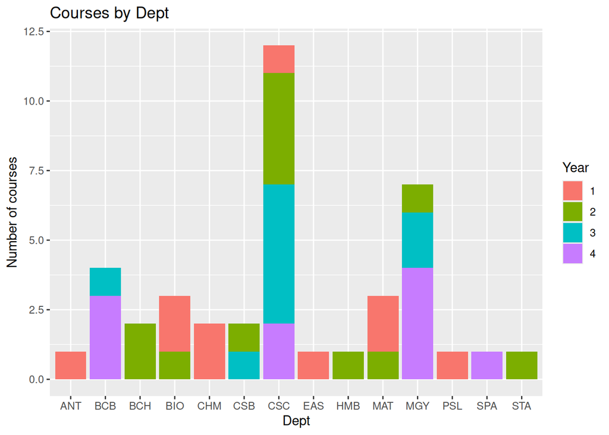

**Figure 1: Courses by Year** Courses according to the year and department.

```r
## organize the data for plotting
# idk what to do here

# generate plot
ggplot2::ggplot(data=courses,
                mapping=aes(x=`Course Dept`,
                            fill=as.factor(`Year`))) +
  ggplot2::geom_bar(position="stack",
                    show.legend=T) +
  ggplot2::labs(title="Courses by Dept",
                x="Dept",
                y="Number of courses",
                fill="Year")
```

## Hobbies

### What are my hobbies?

I have a lot of dumb hobbies! They have changed over the years but generally all loser activities.

```r
paged_table(hobbies, options=list(rows.print=5))
```

| hobby | hours_per_week |
| --- | --- |
| listening to music | 168 |
| doomscrolling | 168 |
| playing genshin impact | 168 |
| playing honkai star rail | 168 |
| playing umamusume | 168 |
| playing project sekai | 168 |
| playing switch | 168 |
| programming single use (aka relatively useless) toy programs | 5 |
| drawing | 10 |
| playing bass | 10 |

[output cut: 3 more lines]

### My Fav Hobby

Ermm… playing games? Listening to music? I also like baking!

## Custom section

I drew this!

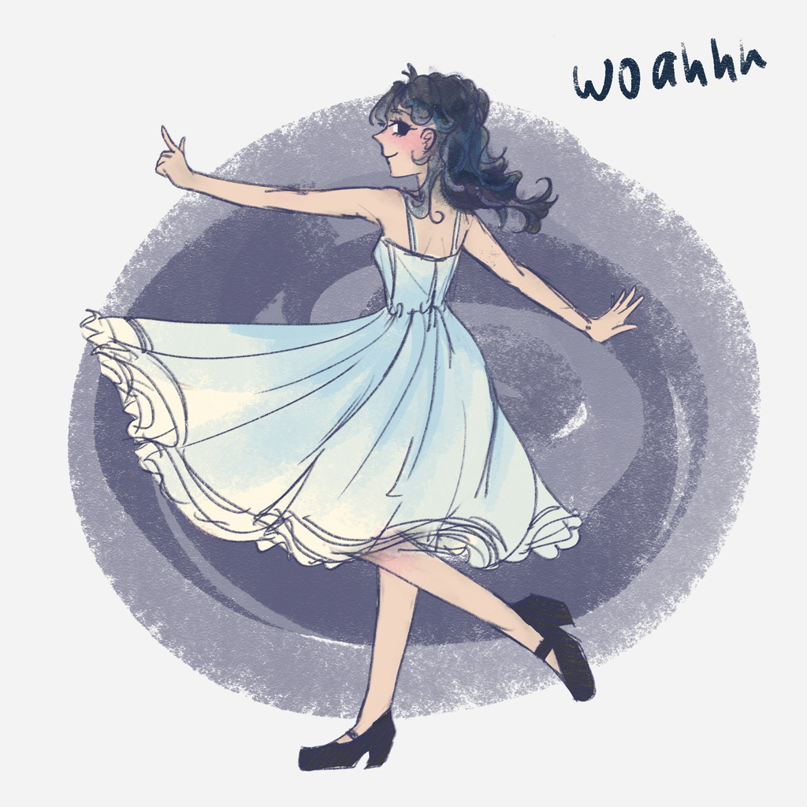

I also drew this!

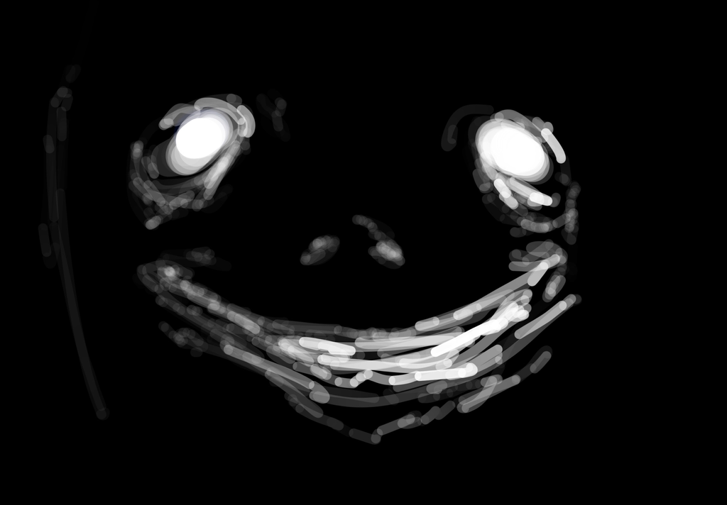

## Questions to answer

1.What is your bachelors degree? Honours Bachelors of Science? My programs are BCB, MoGen and CS!

2.Which courses have you taken and in which departments? A lot…

3.What are your hobbies? A lot too…

4.How many hours a week do you spend on each hobby? A lot!

5.What is your favorite hobby? Listening to music maybe??

6.Add a custom section of your choosing! I put some stuff I drew

## References

Inaka, Kengo, and Tohru Kimura. 2021. “Comfortable and Dermatological Effects of Hot Spring Bathing Provide Demonstrative Insight into Improvement in the Rough Skin of Capybaras.” *Scientific Reports* 11 (1). https://doi.org/10.1038/s41598-021-03102-4.

Wickham, Hadley. 2016. *Ggplot2: Elegant Graphics for Data Analysis*. Springer-Verlag New York. https://ggplot2.tidyverse.org.

Wickham, Hadley, Romain François, Lionel Henry, Kirill Müller, and Davis Vaughan. 2023. *Dplyr: A Grammar of Data Manipulation*. https://doi.org/10.32614/CRAN.package.dplyr.